# E-commerce Data Analysis Preview

Mohamed Saleh Mehimmedetsi

2025-11-16

## 1. Introduction:

This repository serves as a **public preview** of my full Data Analysis Project for ecommerce operations in Algeria and Africa.  
The goal of this preview is to showcase a sample of the **RStudio code**, **workflow**, and **analytical insights** used in the main private project, without exposing sensitive or confidential business data.

The R Markdown document you are reading includes: - Selected and simplified R code excerpts from the main RStudio project files (Ecommerce, Ecommerce 2, Ecommerce 3). - Example visualizations and KPI calculations. - A demonstration of my analysis methodology, including data cleaning, transformation, and insights generation. - Summaries of findings related to advertising performance, product profitability, delivery operations, and revenue estimation.

The full project contains more detailed financial models, full datasets, and advanced exploratory analysis.  
This preview focuses on **transparency**, **methodology**, and **demonstrating technical competency**, while keeping the core business data private.

### 2.4. Africa — Weighted CPM Analysis

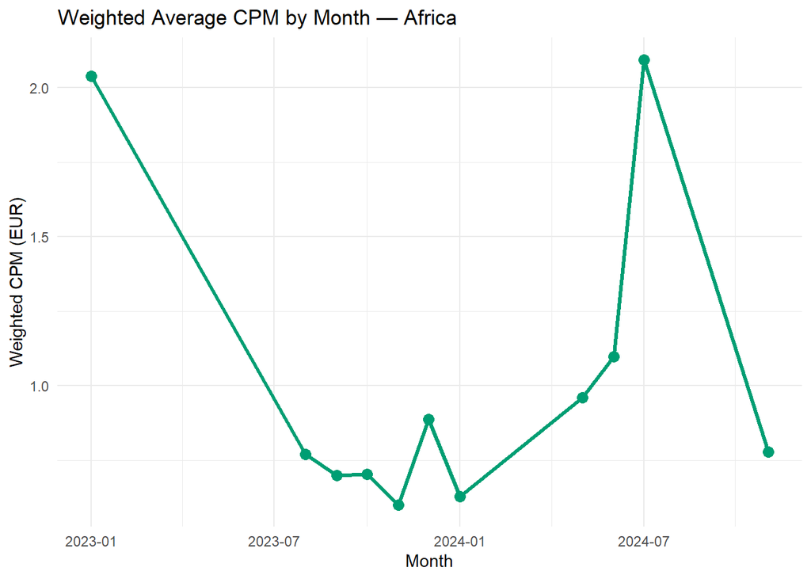

```r
# Load libraries
library(readxl)
library(dplyr)
library(lubridate)
library(ggplot2)

# === Africa Data ===
file_path <- "Facebook.xlsx"
africa <- read_excel(file_path, sheet = "Africa")

# Compute weighted CPM per month
africa_cpm <- africa %>%
  mutate(
    month = floor_date(as.Date(Date, format = "%Y-%m-%d"), "month")
  ) %>%
  group_by(month) %>%
  summarise(
    total_spend = sum(`Amount spent (EUR)`, na.rm = TRUE),
    weighted_cpm = sum(`CPM (EUR)` * `Amount spent (EUR)`, na.rm = TRUE) /
                   sum(`Amount spent (EUR)`, na.rm = TRUE)
  ) %>%
  filter(total_spend > 0)

# Plot weighted CPM by month
ggplot(africa_cpm, aes(x = month, y = weighted_cpm)) +
  geom_line(color = "#009E73", size = 1.2) +
  geom_point(color = "#009E73", size = 3) +
  labs(
    title = "Weighted Average CPM by Month — Africa",
    x = "Month",
    y = "Weighted CPM (EUR)"
  ) +
  theme_minimal()
```

#### 2.3.2 Africa: Store-Level Dominance

In Africa, the strategy was the opposite: a **single, consistent video ad and copywriting style** was used across campaigns, reducing variation at the creative level.  
However, the **landing page experience** became the differentiator, as all traffic was directed to a **Shopify store page template**.

Because the creative input was constant, differences in performance were primarily influenced by what happened **after the click** — such as how efficiently users engaged and converted on the store.  
As a result, **Landing Page Views** and **Cost per Landing Page View** emerged as the dominant factors, indicating that **store-level interactions** and user journey optimization were the key drivers of success in this market.